# Introdução à economia

Aula 17 - Mensurando a renda de uma nação

Prof. Roberto de Freitas Neder

## Aula 17: roteiro

**Mensurando a renda de uma nação** · Mankiw, capítulo 23 · UnB

- Renda, despesa e produção
- O que entra na conta
- Componentes do PIB
- Da renda e da despesa à poupança e ao investimento
- Preços e quantidades
- PIB e bem-estar
- Conclusão
- Exercícios de concursos públicos

Use as setas para trocar de slide. Nas páginas longas, role o conteúdo. As respostas das atividades ficam fechadas até o clique.

## 01 - A economia como um conjunto

Na microeconomia, estudamos decisões de famílias e empresas e o funcionamento de mercados específicos. A **macroeconomia** reúne essas decisões para estudar produção, renda, emprego, preços e crescimento da economia.

Um aumento das vendas de uma empresa pode resultar de mais produção ou de preços maiores. A mesma distinção aparece quando avaliamos um país.

Nesta aula, construiremos o **Produto Interno Bruto (PIB)** e aprenderemos a separar quantidade, preço e bem-estar.

**Base:** Mankiw, 8ª edição, capítulo 23, *Measuring a Nation’s Income*, pp. 473 a 494. No PDF enviado, pp. 502 a 523.

← Menu

## 02 - Uma compra gera uma receita

Quando uma família paga R$ 50 por um corte de cabelo produzido no período, há simultaneamente **R$ 50 de despesa** e **R$ 50 de receita pela produção**.

A receita remunera trabalho, uso de instalações, capital e resultado empresarial. Ao agregar a economia, a despesa com o produto final corresponde à renda gerada na produção.

$$\text{Valor da produção}=\text{Renda gerada}=\text{Despesa final}$$

Essa igualdade é contábil. Ela não significa que toda família gaste exatamente sua renda nem que todas as empresas tenham lucro.

← Menu

## 03 - O fluxo circular

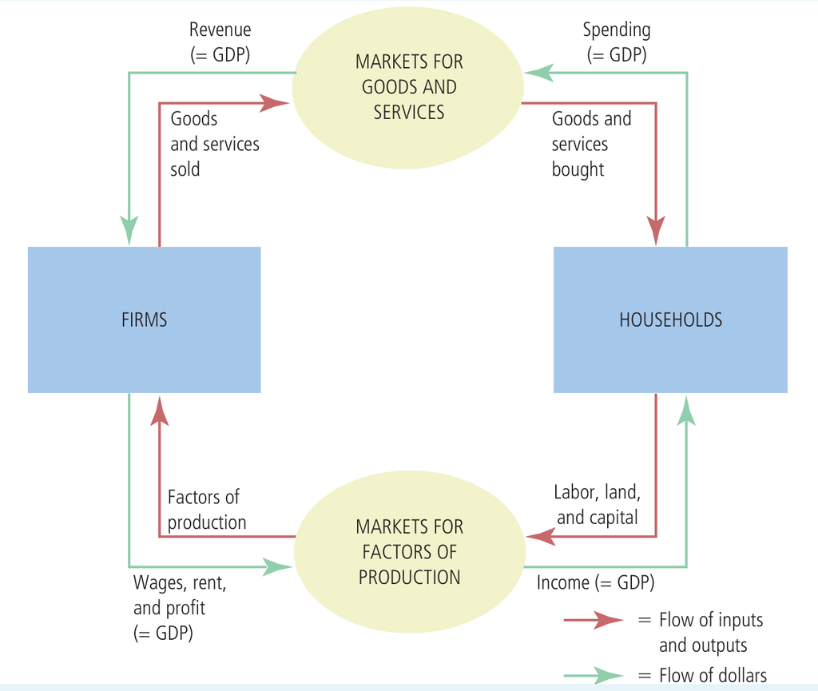

**Firmas (*firms*):** vendem bens e serviços e contratam fatores.

**Famílias (*households*):** compram produtos e oferecem trabalho, terra e capital.

**Fluxo real, em vermelho:** bens, serviços e fatores de produção.

**Fluxo monetário, em verde:** despesas das famílias, salários, aluguéis e lucros.

Neste modelo, as famílias gastam toda a renda.

**Despesa total = renda total = PIB.**

Fonte: Mankiw, *Principles of Economics*, 8ª ed., cap. 23, figura 1, p. 475 (p. 504 do PDF). © Cengage Learning, 2018. Figura original, com rótulos em inglês.

← Menu

## 04 - O significado de PIB

**PIB é o valor de mercado dos bens e serviços finais produzidos dentro de um país em determinado período.**

Cada parte da definição resolve um problema de medição:

- Preços permitem somar produtos fisicamente diferentes.
- “Finais” evita contar o mesmo valor várias vezes.
- “Produzidos” delimita a produção nova.
- “Dentro do país” define o território econômico.
- O período distingue um fluxo de um estoque.

O PIB é bruto porque ainda inclui a parcela necessária para compensar o desgaste do capital.

← Menu

## 05 - Preços como pesos

Não somamos diretamente três consultas médicas e dez quilogramas de arroz. Multiplicamos cada quantidade pelo preço correspondente.

$$PIB_t=\sum_i p_{i,t}q_{i,t}$$

**Exemplo didático:** 10 refeições a R$ 20 e 5 serviços a R$ 60 geram R$ 500 de produção final.

O peso de cada produto depende de seu valor de mercado. Isso permite agregação, mas não mede diretamente importância moral, utilidade individual ou necessidade social. Serviços essenciais podem ter preços baixos ou ser oferecidos gratuitamente.

← Menu

## 06 - Fronteiras da produção

O PIB procura registrar produção de bens e serviços, inclusive parcelas que não passam por uma venda convencional.

| Situação | Tratamento conceitual |
| --- | --- |
| Moradia própria | Imputa-se um serviço de habitação |
| Serviço público sem preço de mercado | A produção é estimada, usualmente pelos custos |
| Cozinhar e cuidar da própria família | Serviços domésticos não remunerados ficam, em geral, fora |
| Trabalho doméstico remunerado | Integra a produção de serviços |

Informalidade e ilegalidade trazem dificuldades de mensuração. **Ausência de registro não equivale à inexistência econômica da atividade.**

← Menu

## 07 - Produtos finais e intermediários

Um bem é intermediário quando entra no processo produtivo de outro bem ou serviço no período. O critério é a **destinação**, não a aparência do produto.

Farinha comprada pela padaria é insumo. Farinha comprada por uma família para uso doméstico é consumo final. Uma máquina usada por vários anos é investimento em capital fixo.

Contar a farinha incorporada ao pão e depois o preço integral do pão duplicaria parte da produção.

Há duas soluções equivalentes: somar os bens finais ou somar o **valor adicionado** em cada etapa.

← Menu

## 08 - Valor adicionado: exemplo resolvido

**Exemplo didático, sem impostos sobre produtos:**

| Etapa | Venda | Insumos intermediários | Valor adicionado |
| --- | --- | --- | --- |
| Produtor de trigo | 100 | 0 | 100 |
| Moinho | 160 | 100 | 60 |
| Padaria | 250 | 160 | 90 |
| Total | 510 | 260 | **250** |

O pão final vale R$ 250. O valor adicionado também soma R$ 250. A soma das vendas, R$ 510, contém dupla contagem.

Nas contas completas, o PIB a preços de mercado combina valor adicionado e impostos líquidos de subsídios sobre produtos.

← Menu

## 09 - Produção nova e estoques

Uma geladeira produzida neste ano e ainda não vendida integra o PIB por meio de **investimento em estoques**. A empresa aparece contabilmente como adquirente de sua produção não vendida.

Quando a geladeira for vendida no ano seguinte, o consumo aumenta e os estoques diminuem. A produção antiga não entra novamente no PIB.

Um automóvel usado também não representa nova produção. Porém, a comissão de uma revendedora pelo serviço prestado agora integra o PIB atual.

**Produzir, vender e pagar podem ocorrer em datas distintas.**

← Menu

## 10 - Território, residência e período

Uma fábrica estrangeira instalada no Brasil contribui para o PIB brasileiro. A nacionalidade de seus proprietários não muda o local da produção.

Já a renda recebida ou enviada ao exterior importa para a **renda nacional**. A distinção relevante envolve residência econômica, não apenas cidadania.

O PIB anual e o PIB trimestral são fluxos. Patrimônio, dívida e estoque de máquinas são grandezas medidas em uma data.

Comparações entre trimestres exigem cuidado com sazonalidade. Uma alta do quarto trimestre pode refletir o calendário, e não uma mudança persistente do ritmo econômico.

← Menu

## 11 - Jogo rápido: entra em qual ano?

Em duplas, justifiquem cada resposta.

1. Uma mesa é produzida em dezembro e vendida em fevereiro. Em qual ano entra a produção?
2. Uma pessoa vende um apartamento antigo. O preço total representa produção nova?
3. Uma agência recebe comissão pela venda. E essa comissão?
4. Um pai passa a cuidar dos filhos sem remuneração após deixar um emprego de cuidador. O cuidado desapareceu?

**Conferir respostas**

1. No ano da produção, como estoque se ainda não vendida. 2. Não. 3. É serviço produzido no período. 4. O trabalho de cuidado permanece, mas o serviço doméstico não remunerado geralmente deixa de aparecer no PIB. Essa fronteira limita a interpretação de bem-estar.

← Menu

## 12 - As quatro parcelas da despesa

$$Y=C+I+G+X-M$$

| Parcela | Conteúdo |
| --- | --- |
| $C$ | Consumo das famílias |
| $I$ | Formação de capital fixo e variação de estoques |
| $G$ | Compras governamentais no modelo do livro |
| $X-M$ | Exportações líquidas |

O investimento público pode ser apresentado dentro de $G$ no modelo didático ou na formação de capital nas contas oficiais. **As classificações precisam ser consistentes para evitar dupla contagem.**

← Menu

## 13 - Consumo das famílias

O consumo reúne bens duráveis, como uma geladeira, bens não duráveis, como alimentos, e serviços, como transporte e educação.

A compra de uma **moradia nova** é investimento residencial. O serviço de morar, inclusive em imóvel próprio mediante imputação, integra consumo de habitação.

Comprar uma ação não é consumir um produto final. Troca-se dinheiro por um ativo financeiro.

Despesas com educação aparecem como consumo nas contas nacionais, embora a análise econômica também as interprete como **investimento em capital humano**. As duas classificações respondem a perguntas diferentes.

← Menu

## 14 - Investimento e patrimônio

Na contabilidade do PIB, investimento é produção de bens que ampliam ou recompõem a capacidade produtiva, construção residencial e variação de estoques.

| Operação | Interpretação |
| --- | --- |
| Empresa compra máquina recém-produzida | Investimento real |
| Família compra apartamento novo | Investimento residencial |
| Pessoa compra ação já existente | Transferência de ativo financeiro |
| Estoque não vendido aumenta | Investimento em estoques |

Uma compra financeira pode financiar investimento futuro. Contudo, **a transação financeira e a produção do bem de capital são registros distintos**.

← Menu

## 15 - Governo: compra e transferência

Serviços prestados por professores da rede pública e a construção de uma escola integram a produção. O governo paga pela utilização atual de fatores e recursos.

Aposentadorias e benefícios em dinheiro são **transferências**. O pagamento, por si só, não compra produção corrente e não entra diretamente em $G$ na identidade didática.

Quando o beneficiário utiliza a renda para comprar alimentos, essa compra aparece em $C$.

Excluir a transferência de $G$ evita duplicação contábil. Não significa que ela seja irrelevante para renda disponível, consumo ou proteção social.

← Menu

## 16 - Importações e exportações

Exportações são produção doméstica adquirida por residentes no exterior. Importações são produção estrangeira adquirida internamente.

Uma família compra um computador importado de R$ 4.000. O registro aumenta $C$ em R$ 4.000 e $M$ em R$ 4.000. O efeito direto sobre o PIB doméstico é zero, desconsiderando serviços e margens internos.

$$\Delta Y=\Delta C-\Delta M=4.000-4.000=0$$

A subtração das importações **corrige sua inclusão nas despesas**. Não demonstra que importar, isoladamente, destrua produção doméstica na mesma magnitude.

← Menu

## 17 - Uma economia em números

**Valores didáticos em bilhões:** $C=600$, $I=180$, $G=220$, $X=100$ e $M=150$.

$$Y=600+180+220+100-150=950$$

As exportações líquidas são $-50$. Ainda assim, o país produz 950. O déficit comercial é apenas um componente da despesa agregada.

Se uma mercadoria produzida internamente no valor de 20 ficar encalhada, seu registro em estoques faz parte de $I$. Não se deve retirar automaticamente esse produto da conta por falta de comprador final.

← Menu

## 18 - Outras medidas de renda

| Medida | Ajuste principal |
| --- | --- |
| Renda Nacional Bruta | PIB mais renda primária líquida recebida do exterior |
| Produto Interno Líquido | PIB menos consumo de capital fixo |
| Renda pessoal | Renda que chega às pessoas, com ajustes institucionais |
| Renda pessoal disponível | Renda pessoal após impostos pessoais, na apresentação do livro |

O livro usa também a denominação **Produto Nacional Bruto**. Na comparação, explicite sempre “interno ou nacional” e “bruto ou líquido”.

Lucros retidos, contribuições e transferências explicam por que PIB e renda disponível das famílias não coincidem.

← Menu

## 19 - Preços de mercado e custo de fatores

Nas identidades tradicionais usadas em concursos, o preço de mercado inclui impostos indiretos líquidos de subsídios. A medida a **custo de fatores** retira essa diferença.

$$PIB_{cf}=PIB_{pm}-\text{impostos indiretos}+\text{subsídios}$$

Para chegar ao produto nacional líquido a custo de fatores, aplicam-se também os ajustes de renda externa e depreciação:

$$PNL_{cf}=PIB_{pm}-RLEE-\text{depreciação}-II+Sub$$

RLEE é a renda líquida enviada ao exterior; II são impostos indiretos; Sub são subsídios.

A terminologia das contas atuais usa medidas a preços básicos e de mercado com classificações próprias de impostos. Na prova, siga as definições fornecidas, sem tratar as classificações como intercambiáveis.

← Menu

## 20 - Da renda e da despesa à poupança

$$\begin{aligned}
Y &\equiv C+G+I+(X-M) \\[5pt]
Y+RLRE &\equiv Y_p^d+R_g \\[5pt]
Y &\equiv Y_p^d+R_g-RLRE \\[7pt]
C+G+I+(X-M) &= Y_p^d+R_g-RLRE \\[7pt]
I &= (Y_p^d-C)+(R_g-G)-[(X-M)+RLRE] \\[7pt]
I &= \underbrace{(Y_p^d-C)}_{S_p}
+\underbrace{(R_g-G)}_{S_g}
-\underbrace{[(X-M)+RLRE]}_{TC} \\[7pt]
I &= S_p+S_g-TC \\[5pt]
\boxed{I=S_p+S_g+S_{ext}} &\qquad S_{ext}\equiv -TC
\end{aligned}$$

**Poupança nacional:** $S_n=S_p+S_g$.

**Economia fechada:** $S_{ext}=0$, portanto $S_n=I$.

$Y_p^d$: renda privada disponível, das famílias e empresas.

$R_g$: renda disponível do governo, líquida de subsídios e transferências.

$RLRE$: renda recebida do exterior **menos** renda enviada.

$TC$: saldo em transações correntes. $X-M$ inclui bens e serviços.

Somente impostos e subsídios: $R_g=T-Sub$.

**$TC>0$:** $S_{ext}<0$. O país **exporta poupança**: $S_n>I$.  
**$TC<0$:** $S_{ext}>0$. O país **importa poupança**: $S_n<I$.

Valores brutos. Neste slide, $G$ é consumo do governo e $I$ inclui investimento público e privado. Supomos nulas as transferências correntes com o exterior. [Referência: FMI](https://www.imf.org/en/publications/fandd/issues/series/back-to-basics/current-account-deficits).

← Menu

## 21 - PIB nominal e PIB real

O **PIB nominal** usa preços e quantidades do próprio ano. Pode crescer por aumento da produção, por alta dos preços ou por ambos.

O **PIB real**, no exemplo de base fixa, avalia as quantidades de cada ano com preços de um mesmo ano-base.

$$Y_t^{nom}=\sum_i p_{i,t}q_{i,t}\qquad Y_t^{real}=\sum_i p_{i,0}q_{i,t}$$

Fixar os preços permite isolar a mudança de volume. Nas estatísticas oficiais, medidas encadeadas refinam o procedimento. A lógica é separar preços e quantidades, sem exigir que toda série use uma base fixa para sempre.

← Menu

## 22 - Exemplo: duas mercadorias

**Economia didática. Ano A como base.**

| Ano | Preço do pão | Quantidade | Preço do suco | Quantidade |
| --- | --- | --- | --- | --- |
| A | 2 | 100 | 5 | 20 |
| B | 3 | 120 | 6 | 30 |

$$Y_A^{nom}=Y_A^{real}=2(100)+5(20)=300$$
$$Y_B^{nom}=3(120)+6(30)=540$$
$$Y_B^{real}=2(120)+5(30)=390$$

O valor nominal cresce **80%**. O volume, medido a preços de A, cresce **30%**. A diferença entre essas taxas não é uma medida exata da inflação.

← Menu

## 23 - O que a comparação mostra

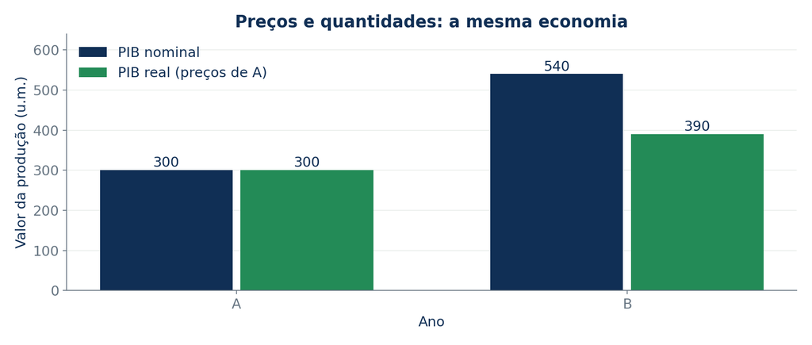

PIB nominal e real no exemplo de pão e suco, com valores de 300 e 540 para o nominal e de 300 e 390 para o real.

Fonte: elaboração didática. Dados hipotéticos, salvo indicação expressa.

O preço constante é a referência que permite atribuir a diferença de 300 para 390 às quantidades. Os R$ 150 restantes no PIB nominal de B decorrem de avaliar as quantidades de B pelos novos preços.

← Menu

## 24 - Deflator do PIB

$$Deflator_t=\frac{PIB_t^{nominal}}{PIB_t^{real}}\times100$$

No ano-base, o índice vale 100. No exemplo:

$$Deflator_B=\frac{540}{390}\times100\approx138{,}46$$

A inflação medida pelo deflator entre A e B é de **38,46%**.

$$1+g_{nominal}=(1+g_{real})(1+\pi)$$

Logo, $1{,}80=1{,}30\times1{,}3846$. Subtrair 80% menos 30% produziria 50%, uma resposta incorreta neste exemplo.

← Menu

## 25 - Crescimento e recessão

$$g_t=\left(\frac{PIB_t^{real}}{PIB_{t-1}^{real}}-1\right)100$$

O PIB real mede a evolução da produção agregada. O PIB real por habitante divide esse produto pela população e aproxima os recursos médios disponíveis por pessoa.

Se o PIB real cresce 3% e a população 1%, o crescimento por habitante é $1{,}03/1{,}01-1\approx1{,}98\%$.

Quedas da atividade ajudam a caracterizar recessões, mas a identificação de um ciclo não se resume a olhar uma única taxa nominal. Compare períodos equivalentes e verifique os ajustes sazonais.

← Menu

## 26 - Jogo rápido: valor ou volume?

1. Todos os preços dobram e as quantidades ficam constantes. O que ocorre com o PIB nominal e o real?
2. O PIB nominal cresce 10% e o deflator cresce 5%. Qual é a variação real exata?
3. O PIB total aumenta, mas a população cresce mais depressa. O PIB por habitante necessariamente aumenta?

**Conferir respostas**

1. O nominal dobra e o real permanece constante. 2. $1{,}10/1{,}05-1\approx4{,}76\%$. A diferença de cinco pontos percentuais é aproximação. 3. Não. A produção média por pessoa pode cair.

← Menu

## 27 - O PIB e as condições de vida

Maior produção por habitante costuma ampliar a possibilidade de consumir, financiar serviços de saúde, estudar e investir em infraestrutura.

O capítulo associa diferenças internacionais de renda a diferenças de qualidade de vida. Essa associação é relevante, mas **não transforma o PIB em uma medida completa de bem-estar**.

Uma média elevada pode conviver com pobreza, desigualdade ou deterioração ambiental. A análise precisa observar a distribuição, o acesso a serviços e as condições em que a produção ocorre.

← Menu

## 28 - O que o indicador deixa de mostrar

| Dimensão | Limitação da leitura isolada do PIB |
| --- | --- |
| Cuidado e trabalho doméstico | Parte importante não recebe preço de mercado |
| Lazer | Mais horas de trabalho podem elevar o PIB e reduzir o tempo livre |
| Ambiente | Degradação e esgotamento de recursos não são abatidos integralmente |
| Distribuição | A média não mostra quem recebe a renda |
| Segurança e vínculos sociais | Não aparecem diretamente como produto |

Após um desastre, reconstruir pode elevar o PIB, embora a sociedade tenha sofrido uma perda patrimonial e humana. **Fluxo de produção e riqueza acumulada são diferentes.**

← Menu

## 29 - Novos produtos e comparações internacionais

Serviços digitais gratuitos, melhorias de qualidade e novos produtos desafiam os procedimentos de mensuração. Preço zero para o usuário não significa benefício zero.

Na comparação entre países, converter rendas pela taxa de câmbio de mercado pode distorcer a comparação de poder de compra. A **paridade do poder de compra** procura considerar diferenças de preços entre economias.

Mesmo em uma unidade comum, compare população, distribuição e oferta de serviços. Os números históricos do livro ilustram mecanismos e não devem ser apresentados como retrato atual do Brasil.

← Menu

## 30 - Contas nacionais no Brasil

O IBGE organiza o Sistema de Contas Nacionais e as Contas Nacionais Trimestrais. As óticas da produção, da despesa e da renda precisam formar um conjunto consistente.

Ao ler uma notícia, identifique:

1. Se a variação é nominal ou de volume.
2. Se compara trimestre anterior, mesmo trimestre do ano anterior ou acumulado.
3. Se há ajuste sazonal.
4. Se o valor é total ou por habitante.

[IBGE: explicação sobre o PIB](https://www.ibge.gov.br/explica/pib.php)

← Menu

## 31 - Conclusão: medir antes de comparar

O PIB organiza a produção em uma conta coerente. Sua construção exige evitar dupla contagem, distinguir produção de transações patrimoniais e separar preços de quantidades.

**Renda, produção e despesa descrevem o mesmo processo agregado por perspectivas diferentes.** Consumo, investimento, compras públicas e exportações líquidas mostram os destinos da produção.

O indicador ajuda a discutir capacidade econômica, mas a avaliação social exige perguntar também quem se beneficia, quais custos ficam fora da conta e como a produção se converte em condições de vida.

As identidades permitem decompor o investimento em poupança privada, pública e externa, distinguindo a poupança nacional da total. Na próxima aula, aprofundaremos as decisões de poupar e investir e o papel do sistema financeiro.

← Menu

## Exercícios de concursos públicos

Oito exercícios selecionados. Nos itens de julgamento, use **C (certo/verdadeiro)** ou **E (errado/falso)**. Leia os enunciados antes de abrir as respostas. As fontes e as adaptações estão identificadas em cada questão.

### Questão 01

FGV, ALE/AM, Analista Legislativo, Economista, 2025, tipo 1 · questão 64

C=400, G=250, capital fixo=150, estoques=10, X=120, M=140. Qual o PIB pela despesa?

1. 780
2. 790
3. 800
4. 820
5. 860

Redação sintetizada para uso didático; dados e resposta preservados.

[Prova original](https://conhecimento.fgv.br/sites/default/files/concursos/analista-legislativo-economista-cns309-tipo-1.pdf) · [Gabarito oficial](https://conhecimento.fgv.br/sites/default/files/concursos/gabarito-definitivo-ale-am.pdf)

Resposta comentada

### Questão 02

FGV, ALE/GO, Analista Legislativo, Economista, 2026, tipo 1 · questão 59

Julgue: I. Produto=renda=despesa; II. PIB=C+I+G+X−M; III. Renda líquida enviada positiva torna PNB maior que PIB; IV. PIL=PIB−depreciação. Quais estão corretas?

1. I e II
2. II e III
3. I, II e IV
4. I, III e IV
5. I e IV

Redação sintetizada para uso didático; dados e resposta preservados.

[Prova original](https://conhecimento.fgv.br/sites/default/files/concursos/analista-legislativo-economista-cns207-tipo-1.pdf) · [Gabarito oficial](https://conhecimento.fgv.br/sites/default/files/concursos/gabarito-definitivo-ale-go.pdf)

Resposta comentada

### Questão 03

FGV, ALE/AM, Analista Legislativo, Economista, 2025, tipo 1 · questão 63

Calcule o produto nacional líquido a custo de fatores: C=800; G=500; capital fixo=300; estoques=20; X=250; M=270; impostos indiretos=90; subsídios=20; depreciação=50; renda enviada=40; recebida=10.

1. 1600
2. 1570
3. 1520
4. 1500
5. 1450

Redação sintetizada para uso didático; dados e resposta preservados.

[Prova original](https://conhecimento.fgv.br/sites/default/files/concursos/analista-legislativo-economista-cns309-tipo-1.pdf) · [Gabarito oficial](https://conhecimento.fgv.br/sites/default/files/concursos/gabarito-definitivo-ale-am.pdf)

Resposta comentada

### Questão 04

CESPE, Senado Federal, Consultor Legislativo, Área 14, 2002 · questão 55, 3º item

Considerando que o PIB nominal de 2000 foi superior ao PIB nominal verificado em 1999, é correto concluir que houve aumento da produção nesse período.

**( ) C ( ) E**

Item original C/E, com normalização de espaçamento. A prova autoriza reprodução com indicação da fonte.

[Prova original](https://cdn.cebraspe.org.br/concursos/_antigos/2002/senado/Arquivos/area_14_LEGISL_1Et.pdf) · [Gabarito oficial](https://cdn.cebraspe.org.br/concursos/_antigos/2002/senado/Arquivos/Gab_Def-SENADO.pdf)

Resposta comentada

### Questão 05

CESPE, Senado Federal, Consultor Legislativo, Área 14, 2002 · questão 55, 1º item

Quando um investidor norte-americano compra ações da EMBRAER no mercado acionário brasileiro, isso representa, para as contas nacionais, um aumento do investimento nacional bruto.

**( ) C ( ) E**

Item original C/E, com normalização de espaçamento. A prova autoriza reprodução com indicação da fonte.

[Prova original](https://cdn.cebraspe.org.br/concursos/_antigos/2002/senado/Arquivos/area_14_LEGISL_1Et.pdf) · [Gabarito oficial](https://cdn.cebraspe.org.br/concursos/_antigos/2002/senado/Arquivos/Gab_Def-SENADO.pdf)

Resposta comentada

### Questão 06

Cebraspe, TCE/PA, Auditor de Controle Externo, Fiscalização, Economia, 2016 · questão 65

As contas de uso da renda mostram a repartição da renda disponível entre consumo e poupança.

**( ) C ( ) E**

Redação sintetizada para uso didático; dados e resposta preservados.

[Prova original](https://cdn.cebraspe.org.br/concursos/TCE_PA_16/arquivos/251TCEPA_027_01.pdf) · [Gabarito oficial](https://cdn.cebraspe.org.br/concursos/TCE_PA_16/arquivos/Gab_Definitivo_251TCEPA_027_01.pdf)

Resposta comentada

### Questão 07

Cebraspe, TCE/PA, Auditor de Controle Externo, Fiscalização, Economia, 2016 · questão 68

O produto agregado reúne bens e serviços finais produzidos em um intervalo de tempo.

**( ) C ( ) E**

Redação sintetizada para uso didático; dados e resposta preservados.

[Prova original](https://cdn.cebraspe.org.br/concursos/TCE_PA_16/arquivos/251TCEPA_027_01.pdf) · [Gabarito oficial](https://cdn.cebraspe.org.br/concursos/TCE_PA_16/arquivos/Gab_Definitivo_251TCEPA_027_01.pdf)

Resposta comentada

### Questão 08

FGV, ALE/PR, Analista Legislativo, Economista, 2024, tipo 1 · questão 42

No fluxo circular simples, identifique fluxo monetário e real correspondentes.

1. Firma remunera fatores; firma compra consumo familiar
2. Firma remunera fatores; firma vende consumo às famílias
3. Família recebe receita de vendas das firmas
4. Família compra consumo; compra fatores
5. Família paga fatores; vende fatores

Alternativas resumidas; corrigida a preposição da alternativa B para explicitar o sentido do modelo. Resposta da banca preservada.

[Prova original](https://conhecimento.fgv.br/sites/default/files/concursos/analista-legislativo-economistae2cns04-tipo-1.pdf) · [Gabarito oficial](https://conhecimento.fgv.br/sites/default/files/concursos/ale-pr-gabarito-definitivo-cargos-do-edital-2.pdf)

Resposta comentada

**Gabarito resumido e resoluções comentadas**

| Questão | 01 | 02 | 03 | 04 | 05 | 06 | 07 | 08 |
| --- | --- | --- | --- | --- | --- | --- | --- | --- |
| Resposta | B | C | E | E | E | C | C | B |

**Questão 01: B**

O investimento inclui capital fixo e estoques: $I=150+10=160$. Logo, $PIB=400+160+250+120-140=790$. As importações retiram produção estrangeira já incluída nos gastos.

Voltar ao enunciado

**Questão 02: C**

I e II expressam identidades contábeis. III inverte o sinal: enviar mais renda do que receber reduz o produto nacional relativamente ao interno. IV retira o consumo de capital fixo.

Voltar ao enunciado

**Questão 03: E**

$PIB_{pm}=800+500+300+20+250-270=1600$. O produto nacional bruto é $1600-40+10=1570$. Retirando depreciação e impostos líquidos: $1570-50-90+20=1450$. São três ajustes distintos: território/residência, bruto/líquido e preços de mercado/custo de fatores.

Voltar ao enunciado

**Questão 04: E**

O PIB nominal combina preços e quantidades. Um aumento pode decorrer inteiramente dos preços. É preciso comparar o PIB real para concluir que aumentou o volume produzido.

Voltar ao enunciado

**Questão 05: E**

Comprar uma ação é uma troca de propriedade financeira. Nas contas nacionais, investimento significa produção de capital fixo e variação de estoques. A empresa pode usar recursos captados para investir, mas são operações diferentes.

Voltar ao enunciado

**Questão 06: C**

A parcela da renda disponível que não é consumida constitui poupança. A conta descreve usos da renda, e não aquisição de ativos financeiros em si.

Voltar ao enunciado

**Questão 07: C**

A referência a bens finais evita dupla contagem. Na agregação monetária, cada produção é valorada; não se somam fisicamente mercadorias heterogêneas.

Voltar ao enunciado

**Questão 08: B**

As firmas remuneram os serviços dos fatores, e as famílias compram os bens e serviços produzidos pelas firmas. Pagamentos e fluxos reais devem ser distinguidos.

Voltar ao enunciado

← Menu